# exam3

Will Schrepferman

4/18/2020

## Question 1

1A) I predict that the correlation coefficient between remittance and outflows and the number of migrants in a given country will be positive; as there are more migrants in a country, more money will be made and sent home in the form of remittances. However, I predict that the relationship will be relatively weak, as there is likely significant variety amongst different immigrant groups and how much money they send in remittances. In order to alleviate this, I would want to control for a country’s standard of living and average wage.

1B)

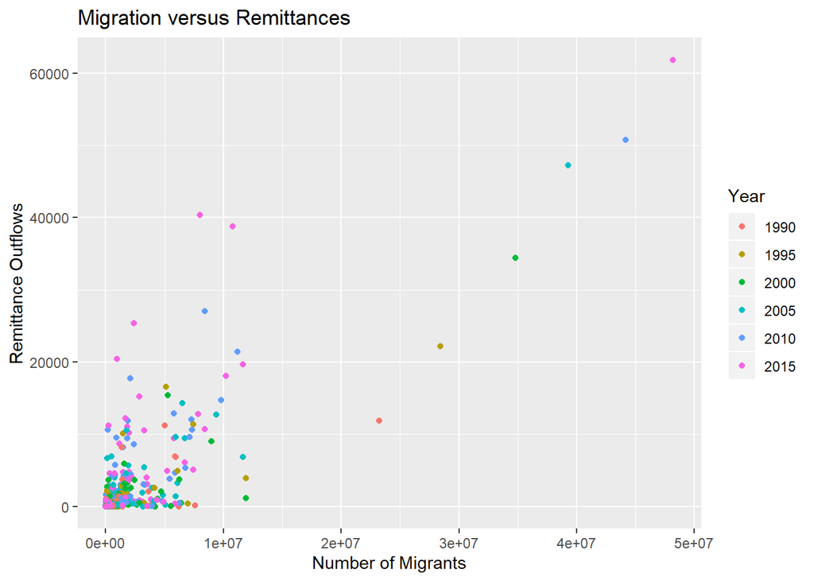

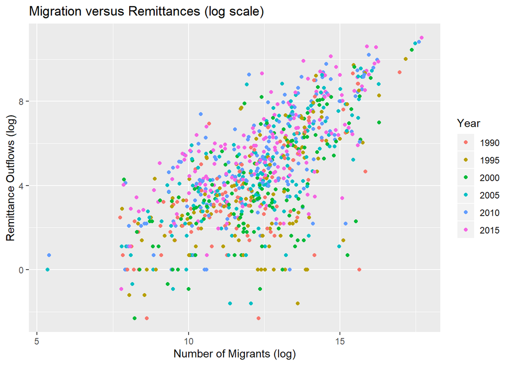

1C)

Correlation Coeffecient per Year

| Year | Correlation Coeffecient |
| --- | --- |
| 1990 | 0.6520407 |
| 1995 | 0.5717538 |
| 2000 | 0.6238396 |
| 2005 | 0.7004822 |
| 2010 | 0.7189968 |
| 2015 | 0.7250154 |

For 2015, my hypothesis was mostly correct. The value of 0.725 is positive, as I predicted; it seems that a higher number of migrants is postively associated with an increase in remittances. However, I predicted that the correlation would be relatively weak, and a value of 0.725 is moderate to strong, implying more of a correlation than I anticipated.

## Question 2

Effect of Number of Migrants on Amount of Remittances

Both IV and DV are logged

| Variable | Estimate | Lower Bound | Upper Bound |
| --- | --- | --- | --- |
| (Intercept) | -5.634995 | -6.4377445 | -4.8322457 |
| log_migrants | 0.835537 | 0.7709453 | 0.9001288 |

2B) Bayesian: The true value for the average treatment effect is somewhere between an estimated percent change of 0.77% and 0.90% in remittances for a percent change in migrants Frequentist: If an infinite number of regressions were run, the interval (0.77, .9) would contain the true interval 95% of the time for the percent change in remittances for a percent change in migrants.

```r
# formula can be seen if I echo the code

predicted_log_remittances_formula <- (-5.634995) + (0.835537*17.69)

newdata <- tibble(log_migrants = 17.69)

predicted_log_remittances_function <- predict(model, newdata = newdata, interval = "prediction", se.fit = FALSE)

predicted_log_remittances_formula
```

```
## [1] 9.145655
```

```r
predicted_log_remittances_function
```

```
##        fit      lwr      upr
## 1 9.145655 5.390989 12.90032
```

## Question 3

3A)

Effect of Number of Migrants on Amount of Remittances

Both IV and DV are logged

| Variable | Estimate | Lower bound | Upper Bound |
| --- | --- | --- | --- |
| (Intercept) | -3.98046336 | -5.76926696 | -2.19165976 |
| log_migrants | 0.61541523 | 0.46696532 | 0.76386514 |
| continentAmericas | -2.45323110 | -4.88922207 | -0.01724013 |
| continentAsia | 1.02999511 | -1.62026693 | 3.68025716 |
| continentEurope | -2.57333277 | -5.28579128 | 0.13912573 |
| continentOceania | -0.06394647 | -2.59119348 | 2.46330054 |
| log_migrants:continentAmericas | 0.28695283 | 0.08195109 | 0.49195456 |
| log_migrants:continentAsia | 0.05064191 | -0.15925901 | 0.26054282 |
| log_migrants:continentEurope | 0.33414486 | 0.12066685 | 0.54762286 |
| log_migrants:continentOceania | 0.13296892 | -0.09610989 | 0.36204773 |

3B) The coefficient for log_migrants means that for a one percent increase in migrants, there is a predicted 0.62 percent increase in remittances. The coeffecient of continentAmericas is the offset in intercept for data from America relative to other continents (the intercept for America is equal to the normal intercept -3.98 plus -2.45). log_migrants:continentAmericas is the offset in predicted-line slope for migrants in the Americas (so 0.615 plus 0.29).

## Question 4

Regression Coefficients Per Year

| Year | Coefficient | Lower | Upper |
| --- | --- | --- | --- |
| 1990 | 0.7646346 | 0.5886005 | 0.9406687 |
| 1995 | 0.7572687 | 0.5595230 | 0.9550144 |
| 2000 | 0.8143625 | 0.6422580 | 0.9864670 |
| 2005 | 0.8740018 | 0.7324398 | 1.0155638 |
| 2010 | 0.8552220 | 0.7279175 | 0.9825264 |
| 2015 | 0.8007526 | 0.6850338 | 0.9164714 |